# GenomicRanges and Related Packages Demo

### GRanges Operations and Visualization

GenomicRanges supports the same range operations as `IRanges`, but it automatically respects boundaries like chromosomes and strands (e.g., intervals on `chr1` will never merge with intervals on `chr2`).

```r
library(dplyr)
## other useful functions
# Coverage calculation across chromosomes
coverage(gr)
```

```
## RleList of length 2
## $chr1
## integer-Rle of length 7 with 3 runs
##   Lengths: 1 5 1
##   Values : 1 2 1
##
## $chr2
## integer-Rle of length 10 with 6 runs
##   Lengths: 2 1 1 4 1 1
##   Values : 0 1 2 3 2 1
```

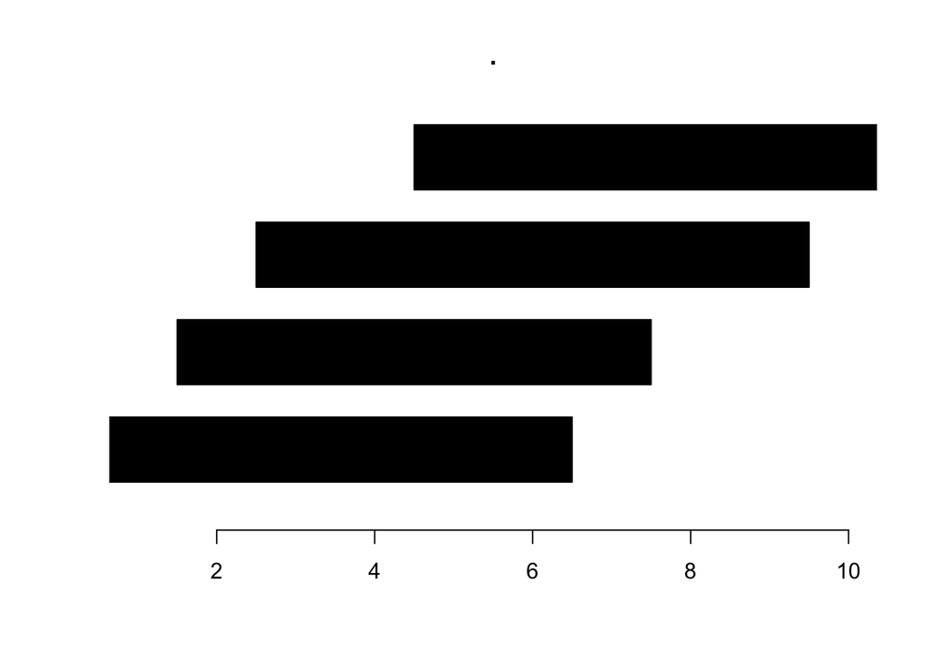

```r
# Reduce, disjoin, flank, and gaps. Notice the use of the %>% pipe for plotting
reduce(gr) %>% plotRanges()
```

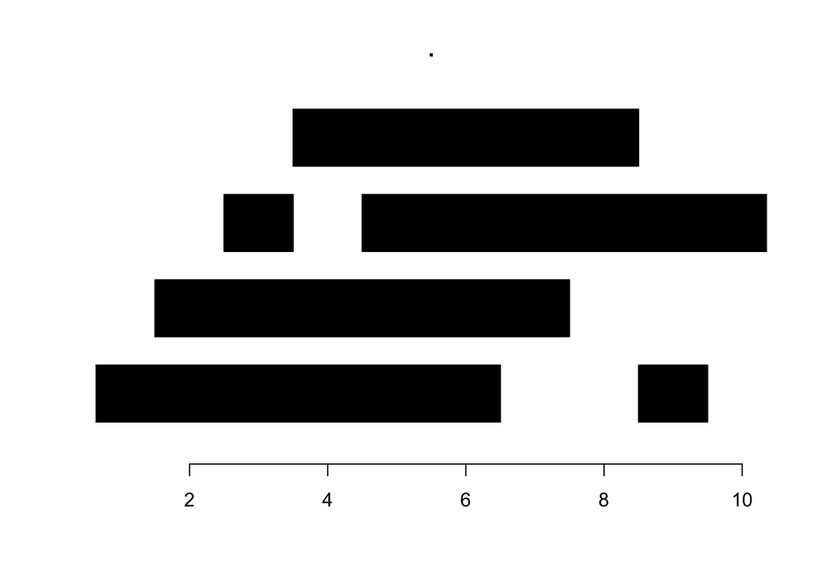

```r
disjoin(gr) %>% plotRanges()
```

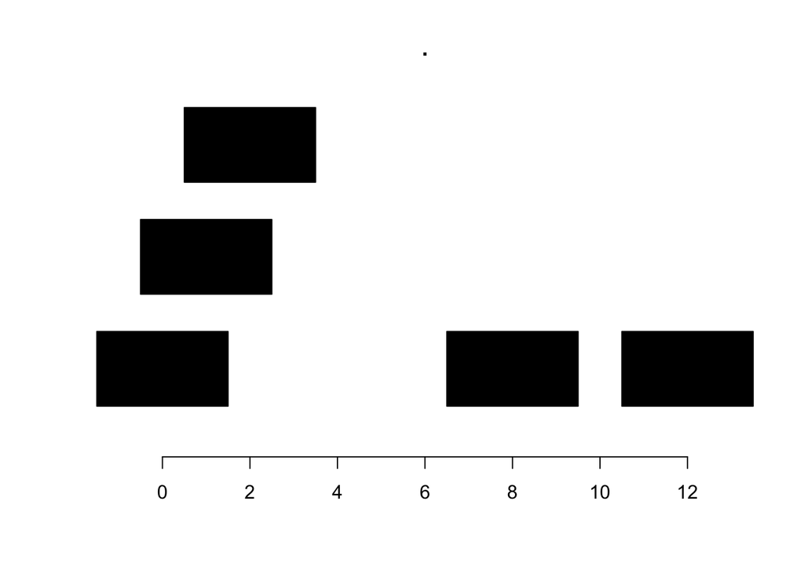

```r
flank(gr, width = 3)  %>% plotRanges()
```

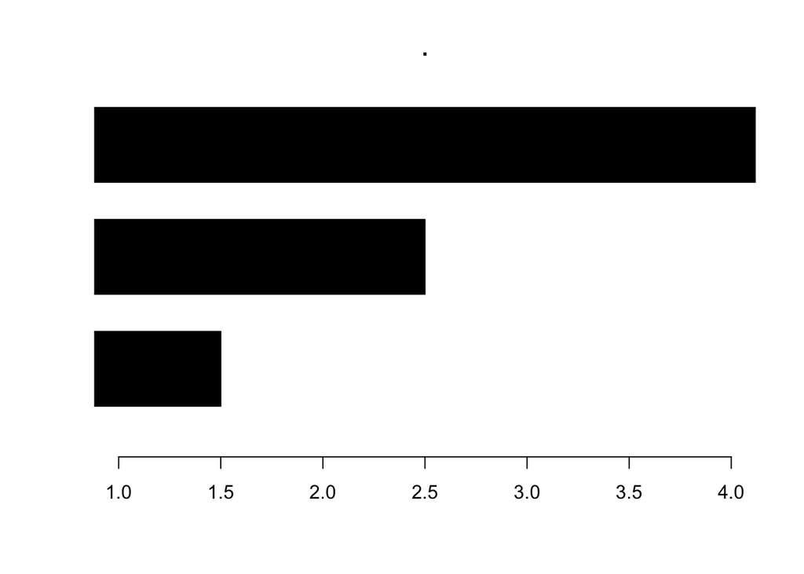

```r
# gaps() finds the empty spaces between intervals on the same chromosome/strand
gaps(gr) %>% plotRanges()
```

### GRanges Set Operations and Overlaps

Demonstrating overlaps and set theory across two `GRanges` objects. Operations only evaluate against matching chromosomes and strands.

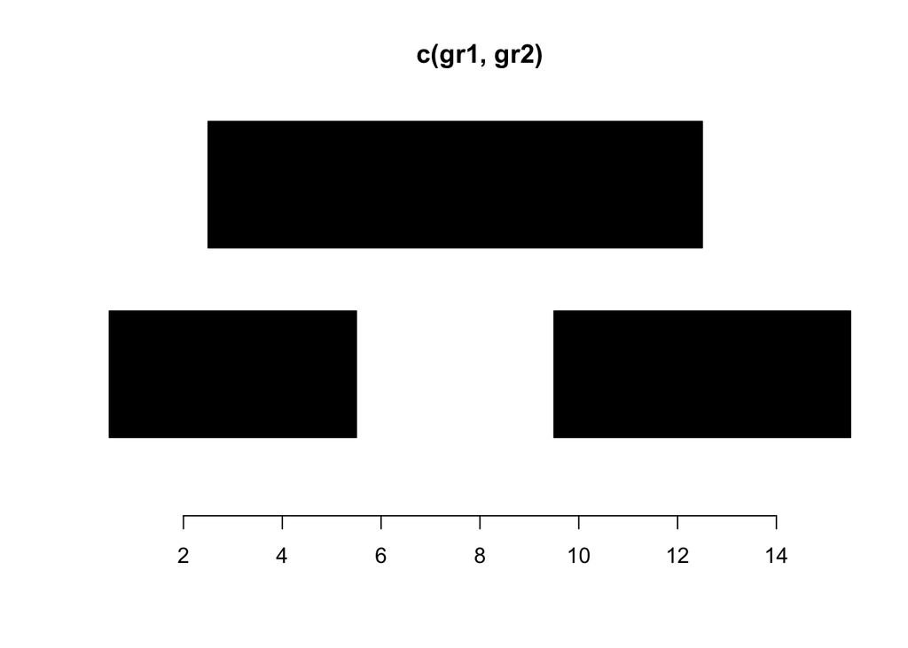

```r
## set operations
gr1 <- GRanges(
  seqnames = Rle("chr1", 2),
  ranges=IRanges(start=c(1,10), end = c(5,15))
)
gr2 <- GRanges(
  seqnames = Rle("chr1", 1),
  ranges = IRanges(start=3, end = 12)
)

# Plot combined ranges
plotRanges(c(gr1, gr2))
```

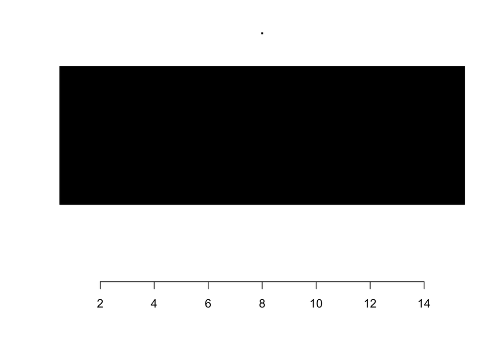

```r
# Perform and plot set operations
union(gr1, gr2)  %>% plotRanges()
```

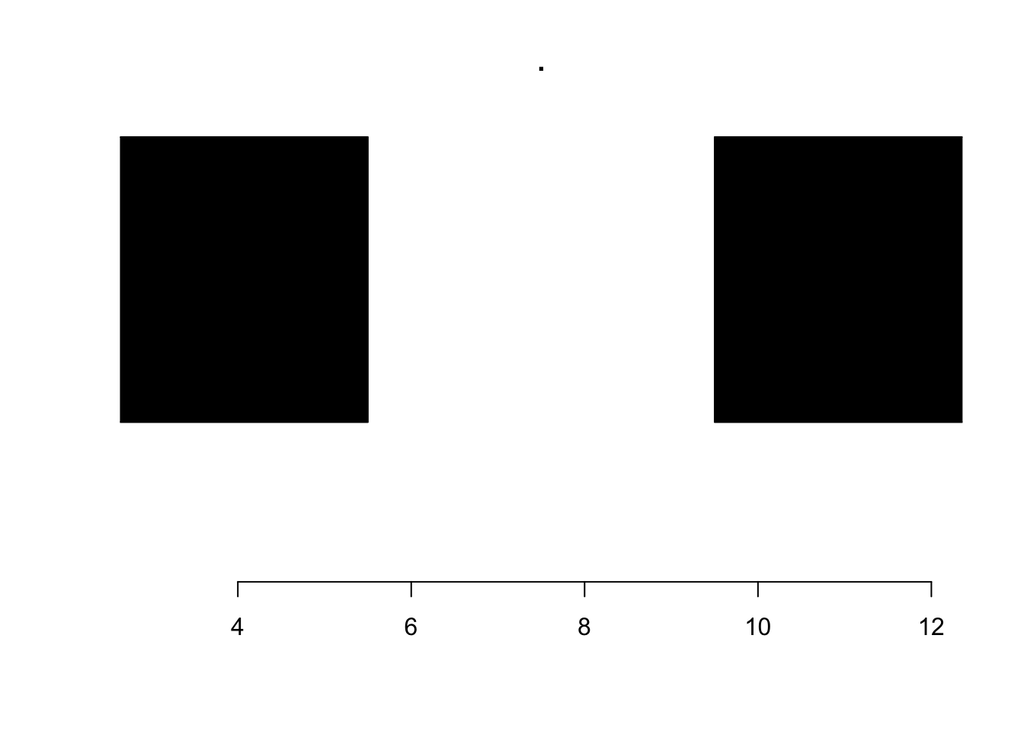

```r
intersect(gr1, gr2) %>% plotRanges()
```

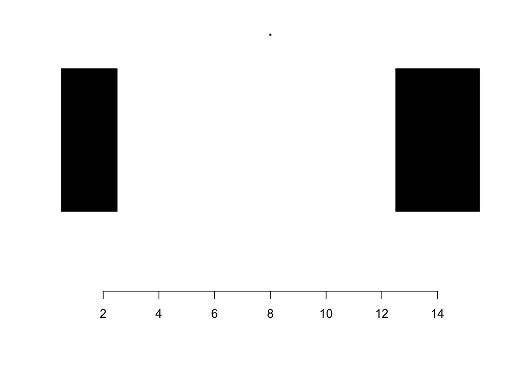

```r
setdiff(gr1, gr2) %>% plotRanges()
```

```r
## find overlaps
# Find detailed hits between gr1 and gr2
findOverlaps(gr1, gr2)
```

```
## Hits object with 2 hits and 0 metadata columns:
##       queryHits subjectHits
##       <integer>   <integer>
##   [1]         1           1
##   [2]         2           1
##   -------
##   queryLength: 2 / subjectLength: 1
```

```r
# Logical check for overlaps
gr1 %over% gr2
```

```
## [1] TRUE TRUE
```

### GRangesList

A `GRangesList` is a container for holding multiple `GRanges` objects, often used to group transcripts by gene or exons by transcript.

```r
##### GRangesList
# Combine multiple GRanges into a single list object
glist = GRangesList(gr1, gr2)
glist
```

```
## GRangesList object of length 2:
## [[1]]
## GRanges object with 2 ranges and 0 metadata columns:
##       seqnames    ranges strand
##          <Rle> <IRanges>  <Rle>
##   [1]     chr1       1-5      *
##   [2]     chr1     10-15      *
##   -------
##   seqinfo: 1 sequence from an unspecified genome; no seqlengths
##
## [[2]]
## GRanges object with 1 range and 0 metadata columns:
##       seqnames    ranges strand
##          <Rle> <IRanges>  <Rle>
##   [1]     chr1      3-12      *
##   -------
##   seqinfo: 1 sequence from an unspecified genome; no seqlengths
```

```r
glist[[1]] # Access the first GRanges object in the list
```

```
## GRanges object with 2 ranges and 0 metadata columns:
##       seqnames    ranges strand
##          <Rle> <IRanges>  <Rle>
##   [1]     chr1       1-5      *
##   [2]     chr1     10-15      *
##   -------
##   seqinfo: 1 sequence from an unspecified genome; no seqlengths
```

```r
glist[[2]] # Access the second GRanges object in the list
```

```
## GRanges object with 1 range and 0 metadata columns:
##       seqnames    ranges strand
##          <Rle> <IRanges>  <Rle>
##   [1]     chr1      3-12      *
##   -------
##   seqinfo: 1 sequence from an unspecified genome; no seqlengths
```

```r
# Apply functions over the list elements
lapply(glist, length) # Returns a standard list of lengths
```

```
## [[1]]
## [1] 2
##
## [[2]]
## [1] 1
```

```r
sapply(glist, length) # Returns a simplified vector of lengths
```

```
## [1] 2 1
```

### GenomicFeatures and Transcript Databases (TxDb)

`GenomicFeatures` allows you to interact with transcript databases (like those from UCSC). Note: The `saveDb`/`loadDb` operations use a local file path which you will need to adjust for your system.

```r
#####################################################
## GenomicFeatures
#####################################################
library(GenomicFeatures)
library(txdbmaker)

## from UCSC
# Check which UCSC tracks are supported for generating databases
supportedUCSCtables()
# Build a Transcript Database (TxDb) straight from the UCSC knownGene table for hg19
txdb = makeTxDbFromUCSC(genome="hg19", tablename="knownGene")
txdb

## save and load
# NOTE: Update 'dataDir' to a valid directory on your machine before running
dataDir <- "/Users/mdozmorov/Documents/Work/Teaching/BIOS668.2018/assets/data"
# Save the database locally as an SQLite file to avoid downloading it again later
saveDb(txdb, file=paste0(dataDir, "/hg19_knownGenes.sqlite")) # Takes a few minutes
# Load the saved database
txdb = loadDb(paste0(dataDir, "/hg19_knownGenes.sqlite"))
txdb

## make TxDb package - this gives a package directory in current folder
# (Commented out) This generates an actual installable R package containing your TxDb
# makeTxDbPackageFromUCSC(maintainer="Hao Wu <hao.wu@emory.edu>", author="Hao Wu",
#                         version="1.0", genome="hg19",tablename="knownGene")

## retrieve basic features
# Extract all transcripts as a GRanges object
transcripts(txdb)
# Extract transcripts, filtering only for chromosome 1
transcripts(txdb, filter=list(tx_chrom="chr1"))
# Extract all exons
exons(txdb)

# Group features into GRangesLists (e.g., all transcripts grouped by their parent gene)
transcriptsBy(txdb, by="gene")
exonsBy(txdb, by="gene")
intronsByTranscript(txdb)
fiveUTRsByTranscript(txdb)
threeUTRsByTranscript(txdb)

## by overlap
# Define a region of interest
gr = GRanges(
  seqnames = Rle("chr1", 2),
  ranges=IRanges(start=c(100000,500000), end = c(200000,600000))
)
gr
# Retrieve only the transcripts that overlap with our region of interest
transcriptsByOverlaps(txdb, gr)
```